# Algoritmo EM em Modelos de Misturas

Autor

Milena Paz Freitas

# 1. Formulação do Modelo como Estrutura de Dados Incompletos

Como descrito por McLachlan; Krishnan (2008), a mistura (univariada) com $n$ dados observados $\bm y=(y_1,...,y_n)$ pode ser formulada pela composição com uma variável $\bm Z$ latente que indique a qual “grupo” cada observação pertence, de forma que os dados completos sejam $\bm{y_c}= (\bm y^\intercal,\bm z^\intercal)$. Essa formulação se inspira em um método de geração de misturas que, de acordo com Basso; Dávila (2010), considera uma variável aleatória $\bm Z_i$ categórica e $g$-dimensional pela qual a densidade de $Y_i$ é condicionada:

$$Z_{ij}=
\begin{cases}
1\text{, se } Y_i\text{ pertence ao grupo } j
\\
0\text{, c.c.}
\end{cases};\quad j=1,...,g.\quad i=1,...,n.$$
Ou seja, $\bm Z_i$ é multinomial com pesos $\bm p=(p_1,...,p_g)$ e tamanho $n=1$. Logo, sua função de probabilidades (marginal) é dada por: $\text{ }p(\bm z_i)= \prod^g_{j=1} p_j^{z_{ij}}$. Assim, podemos dizer que a função densidade de probabilidade de $Y_i$ condicionada por $\bm Z_i$ é:

$$f(y_i|\bm\theta,\bm z_i)= \prod^g_{j=1}p_j^{z_{ij}}f_j(y_i|\bm \theta_j)^{z_{ij}},$$

onde $\theta_j$ são os parâmetros de $y_i$ correspondentes ao grupo $j$ e $f_j$ as densidades componentes da mistura. A função de verossimilhança completa, considerando $Y_i$ independentes e identicamente distribuidos, seria:

$$L_c(\bm p, \bm \theta)=\prod^n_{i=1}\prod^g_{j=1}\left[p_jf_j(y_i|\bm \theta_j)\right]^{z_{ij}}$$

Logo:

$$l_c(\bm p,\bm\theta)= \sum^g_{j=1}\sum^n_{i=1}z_{ij}\left[\log p_j+\log f_j(y_i|\bm \theta_j)\right]$$

é a log-verossimilhança completa.

# 2. Algoritmo EM em Modelos de Misturas

Usando a estrutura acima, podemos aplicar o algoritmo EM ou alguma extensão do mesmo. Digamos que $\bm \Psi=(\bm p,\bm \theta)$ , a função esperança da log-verossimilhança completa condicionada em $\bm y$ é como segue:

$$\begin{aligned}
Q(\bm \Psi|\bm{\Psi^{(k)}})&=\text E [l_c(\bm \Psi)|\bm y, \bm \Psi^{(k)}]
\\
&=\sum^g_{j=1}\sum^n_{i=1}\text{E}[z_{ij}|\bm y,\bm \Psi^{(k)}]\left(\log p_j^{(k)}+\log f_j(y_i|\bm \theta_j^{(k)})\right)
\\
&=\sum^g_{j=1}\sum^n_{i=1}\hat{z}_{ij}\left(\log p_j^{(k)}+\log f_j(y_i|\bm \theta_j^{(k)})\right)
\end{aligned}$$

Onde $\hat z_{ij}$ é a probabilidade *a posteriori* do $i$-ésimo valor observado ($y_i$) fazer parte do $j$-ésimo grupo, ou seja:

$$\hat z_{ij}= \text{P}(Z_{ij}=1|\bm y,\bm \Psi) =
\frac{p_{j}^{(k)} f_j(y_i|\bm \theta_j^{(k)})}{\sum^g_{h=1} p_h^{(k)} f_h(y_i|\bm \theta_h^{(k)})}$$

Considerando apenas os pesos $\bm p$ como desconhecidos, a etapa E seria encontrar esse $\hat z_{ij}$, enquanto a etapa M consistiria em obter $\hat{\bm{p}}^{(k+1)}$. Como obtido anteriormente, o estimador de máxima verossimilhança para $\bm{p}$ é $\hat{ \bm{p}}=\left(\frac{\sum^n_{i=1}z_{i1}}{n},...,\frac{\sum^n_{i=1}z_{ig}}{n}\right)$. Logo, temos para o passo M:

$$\hat{ \bm{p}}^{(k+1)}= \left(\sum^n_{i=1}\hat{z}_{i1}/n,...,\sum^n_{i=1}\hat z_{ig}/n\right)$$

## 2.1 Exemplo: Mistura Normal com Duas Componentes (médias e variâncias conhecidas)

Vamos gerar uma mistura gaussiana no R e usar o algoritmo EM para estimar os pesos. Usando o método de geração pela multinomial para uma mistura $0.64\mathcal{N}(160, 15) + 0.36\mathcal{N}(173, 12)$, temos os seguintes dados:

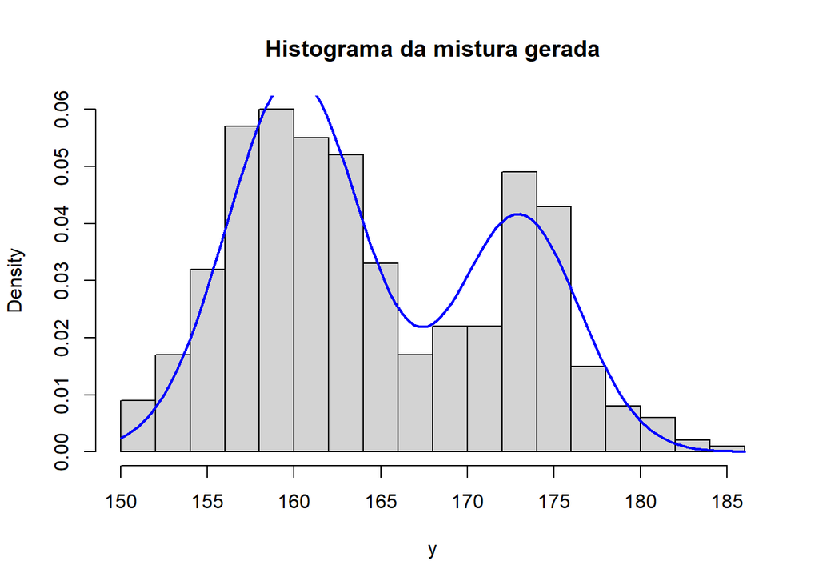

```r
#Fixando os parâmetros
P <- c(0.64,0.36)
mu <- c(160,173)
sigma <- sqrt(c(15,12))
n<- 500

grupos <- t(rmultinom(n, 1, prob=P))
y <- numeric(n)
for(i in 1:2)
  y[as.logical(grupos[,i])] <- rnorm(sum(grupos[,i]), mu[i],sigma[i])


hist(y,freq=F,breaks=20, main="Histograma da mistura gerada")
curve(P[1]*dnorm(x,mu[1],sigma[1]) + P[2]*dnorm(x,mu[2],sigma[2]),add=T,col="blue",lwd=2)
```

Agora, implementando o algoritmo EM como foi enunciado na Seção 2, temos:

```r
l <- function(p){
  sum(log(p[1]*dnorm(y,mu[1],sigma[1])+p[2]*dnorm(y,mu[2],sigma[2])))
}

crit <- function(ll,p){
  ll2 <- l(p)
  abs(ll2-ll)/(abs(ll) + 1e-8) > 1e-7
}

component <- function(x,g){
  dnorm(x,mu[g],sigma[g])
}

EM <- function(p){
  cont<-1
  l1<-100
  z <- 1
  while(crit(l1,p)){
    #--------PASSO E--------#
    z <- sapply(y,function(y){
      sapply(1:2,function(j) p[j]*component(y,j)/sum(p[1]*component(y,1),p[2]*component(y,2)))
    })
    #-----------------------#
    l1<- l(p)
    #--------PASSO M--------#
    p <- apply(z,1,mean)
    #-----------------------#
    cat("Iteração ",cont,": phat=",p,"\n")
    cont<-cont+1
  }
  return(p)
}

#chute inicial de equiprobabilidade
EM(c(0.5,0.5))
```

```
Iteração  1 : phat= 0.6382967 0.3617033
Iteração  2 : phat= 0.6521765 0.3478235
Iteração  3 : phat= 0.6536129 0.3463871
Iteração  4 : phat= 0.6537626 0.3462374
```

```
[1] 0.6537626 0.3462374
```

## 2.2. Exemplo: Mistura Normal com Duas Componentes (médias e variâncias desconhecidas)

Suponhamos que seja a mesma mistura em 2.1, mas dessa vez não se sabe os parâmetros das componentes (apenas o número de componentes). O passo E segue idêntico, mas agora o passo M envolve encontrar os estimadores de máxima verossimilhança de $\mu_1, \mu_2$ e $\sigma^2_1,\sigma^2_2$:

$$l_c(\bm \Psi)=
\sum^g_{j=1}\sum^n_{i=1}z_{ij}\left\{\log p_j-\frac{1}{2}\left[\log\sigma^2_j-\frac{(y_i-\mu_j)^2}{\sigma^2_j}\right]+c\right\},$$

onde $c$ é uma constante em relação a $\bm \Psi=(\bm p,\bm \mu,\bm \sigma)$. Logo, temos que:

$$\begin{aligned}
Q(\bm \Psi|\bm{\Psi^{(k)}})&=\text E [l_c(\bm \Psi)|\bm y, \bm \Psi^{(k)}]
\\
&=\sum^g_{j=1}\sum^n_{i=1}\hat z_{ij}\left\{\log p_j-\frac{1}{2}\left[\log\sigma^2_j+\frac{(y_i-\mu_j)^2}{\sigma^2_j}\right]+c\right\}
\end{aligned}$$

Logo, para o passo M:

$$\frac{dQ(\bm \Psi|\bm{\Psi^{(k)}})}{d\mu_j}=\sum^n_{i=1}\hat z_{ij}\frac{(y_i-\mu_j)}{\sigma^2_j}$$

$$\Rightarrow \frac{\sum^n_{i=1}z_{ij}^{(k)}(y_i-\mu_j^{(k+1)})}{{\sigma^2_j}^{(k)}}=0
\Rightarrow \sum^n_{i=1}\hat z_{ij}^{(k)}y_i=\sum^n_{i=1}\hat z_{ij}^{(k)}\mu_j^{(k+1)}$$

$$\Rightarrow
\mu_j^{(k+1)}=\frac{\sum^n_{i=1}\hat z_{ij}^{(k)}y_i}{\sum^n_{i=1}\hat z_{ij}^{(k)}}
\tag{1}$$

$$\frac{dQ(\bm \Psi|\bm{\Psi^{(k)}})}{d\sigma^2_j}=
\sum^n_{i=1}z_{ij}\left[-\frac{1}{2\sigma^2_j}+\frac{(y_i-\mu_j)^2}{2({\sigma^2_j})^2}\right]$$

$$\Rightarrow \sum^n_{i=1}z_{ij}^{(k)}\left[-\frac{1}{2{\sigma^2_j}^{(k+1)}}+\frac{(y_i-\mu_j^{(k+ 1)})^2}{2({\sigma^2_j}^{(k+1)})^2}\right]=0\Rightarrow
\frac{\sum^n_{i=1}z_{ij}^{(k)}(y_i-\mu_j^{(k+1)})^2}{{\sigma^2_j}^{(k+1)}}=\sum^n_{i=1}z_{ij}^{(k)}$$

$$\Rightarrow {\sigma^2_j}^{(k+1)}=\frac{\sum^n_{i=1}z_{ij}^{(k)}(y_i-\mu_j^{(k)})^2}{\sum^n_{i=1}z_{ij}^{(k)}}
\tag{2}$$

Assim temos o seguinte algoritmo:

1. **Passo E**: Calcula-se $\hat z_{ij}=\frac{p_{j}^{(k)} f_j(y_i|\mu_j^{(k)},{\sigma_j^2}^{(k)})}{\sum^g_{h=1} p_h^{(k)}f_h(y_i|\mu_j^{(k)},{\sigma_j^2}^{(k)})},\quad i=1,...,n\quad j=1,...,g$;
2. **Passo M**: Obtem-se $\bm \mu^{(k+1)},\bm {\sigma^2}^{(k+1)}$ que maximizem a função $Q$, ou seja, calculam-se os pontos críticos da Equação 1 e Equação 2.
3. Verifica-se se o critério de parada. Caso seja falso, retorna-se ao passo 1.

```r
#usando os mesmos dados do exemplo 2.1
l <- function(p,mu,sigma){
  sum(log(p[1]*dnorm(y,mu[1],sigma[1])+p[2]*dnorm(y,mu[2],sigma[2])))
}

crit <- function(ll,p,mu,sig){
  ll2 <- l(p,mu,sig)
  abs(ll2-ll)/(abs(ll) + 1e-8) > 1e-6
}

component <- function(x,mu,sig,g){
  dnorm(x,mu[g],sqrt(sig[g]))
}

EM <- function(p,mu,sig){
  cont<-1
  l1<-100
  z <- 1
  while(crit(l1,p,mu,sig)){
    #--------PASSO E--------#
    z <- sapply(y,function(y){
      sapply(1:2,function(j) p[j]*component(y,mu,sig,j)/sum(p[1]*component(y,mu,sig,1),
                                                            p[2]*component(y,mu,sig,2)))
    })
    #-----------------------#
    l1<- l(p,mu,sig)
    #--------PASSO M--------#
    p <- apply(z,1,mean)
    mu <- apply(z,1,function(z) sum(z*y)/sum(z))
    sig <- sapply(1:2, function(j)
      sum(z[j,]*(y-mu[j])^2)/sum(z[j,]))
    #-----------------------#
    cat("Iteração ",cont,": phat=",p," muhat= ", mu,"sigma2hat", sig,"\n")
    cont<-cont+1
  }
  return(cbind(p,mu,sig))
}

#chute baseado no histograma
EM(c(0.3,0.7),c(175,158),c(10,10))
```

```
Iteração  1 : phat= 0.3525872 0.6474128  muhat=  173.4427 159.5466 sigma2hat 12.16998 14.15631
Iteração  2 : phat= 0.3493122 0.6506878  muhat=  173.4285 159.6241 sigma2hat 12.81778 14.9751
Iteração  3 : phat= 0.3478306 0.6521694  muhat=  173.438 159.6505 sigma2hat 12.89683 15.22089
Iteração  4 : phat= 0.3468782 0.6531218  muhat=  173.4513 159.6635 sigma2hat 12.85666 15.32107
Iteração  5 : phat= 0.3461648 0.6538352  muhat=  173.4636 159.672 sigma2hat 12.79735 15.37714
Iteração  6 : phat= 0.3455997 0.6544003  muhat=  173.474 159.6784 sigma2hat 12.74231 15.41631
Iteração  7 : phat= 0.3451438 0.6548562  muhat=  173.4826 159.6835 sigma2hat 12.69592 15.44664
Iteração  8 : phat= 0.3447742 0.6552258  muhat=  173.4896 159.6876 sigma2hat 12.65792 15.47099
Iteração  9 : phat= 0.3444743 0.6555257  muhat=  173.4953 159.6909 sigma2hat 12.62707 15.49076
Iteração  10 : phat= 0.3442311 0.6557689  muhat=  173.4999 159.6937 sigma2hat 12.60211 15.50685
Iteração  11 : phat= 0.344034 0.655966  muhat=  173.5036 159.6959 sigma2hat 12.58194 15.51993
Iteração  12 : phat= 0.3438743 0.6561257  muhat=  173.5066 159.6976 sigma2hat 12.56564 15.53057
Iteração  13 : phat= 0.3437451 0.6562549  muhat=  173.509 159.6991 sigma2hat 12.55247 15.53919
Iteração  14 : phat= 0.3436406 0.6563594  muhat=  173.511 159.7002 sigma2hat 12.54184 15.54619
Iteração  15 : phat= 0.343556 0.656444  muhat=  173.5126 159.7012 sigma2hat 12.53326 15.55186
Iteração  16 : phat= 0.3434877 0.6565123  muhat=  173.5139 159.702 sigma2hat 12.52632 15.55644
Iteração  17 : phat= 0.3434324 0.6565676  muhat=  173.5149 159.7026 sigma2hat 12.52073 15.56016
Iteração  18 : phat= 0.3433878 0.6566122  muhat=  173.5158 159.7031 sigma2hat 12.51621 15.56316
Iteração  19 : phat= 0.3433517 0.6566483  muhat=  173.5164 159.7035 sigma2hat 12.51256 15.56559
Iteração  20 : phat= 0.3433226 0.6566774  muhat=  173.517 159.7038 sigma2hat 12.50961 15.56755
Iteração  21 : phat= 0.343299 0.656701  muhat=  173.5174 159.7041 sigma2hat 12.50723 15.56914
Iteração  22 : phat= 0.34328 0.65672  muhat=  173.5178 159.7043 sigma2hat 12.50531 15.57042
Iteração  23 : phat= 0.3432647 0.6567353  muhat=  173.5181 159.7045 sigma2hat 12.50376 15.57146
Iteração  24 : phat= 0.3432523 0.6567477  muhat=  173.5183 159.7046 sigma2hat 12.5025 15.57229
Iteração  25 : phat= 0.3432423 0.6567577  muhat=  173.5185 159.7047 sigma2hat 12.50149 15.57297
Iteração  26 : phat= 0.3432342 0.6567658  muhat=  173.5186 159.7048 sigma2hat 12.50068 15.57351
Iteração  27 : phat= 0.3432276 0.6567724  muhat=  173.5188 159.7049 sigma2hat 12.50002 15.57395
Iteração  28 : phat= 0.3432224 0.6567776  muhat=  173.5189 159.7049 sigma2hat 12.49948 15.57431
Iteração  29 : phat= 0.3432181 0.6567819  muhat=  173.5189 159.705 sigma2hat 12.49905 15.5746
Iteração  30 : phat= 0.3432147 0.6567853  muhat=  173.519 159.705 sigma2hat 12.49871 15.57483
Iteração  31 : phat= 0.3432119 0.6567881  muhat=  173.5191 159.705 sigma2hat 12.49843 15.57502
```

```
             p       mu      sig
[1,] 0.3432119 173.5191 12.49843
[2,] 0.6567881 159.7050 15.57502
```

## Referências

BASSO, R. M.; DÁVILA, V. H. L. **Misturas finitas de misturas de escala skew-normal**. tese de doutorado—SP: Dissertação de Mestrado-Universidade Estadual de Campinas, 2010.

MCLACHLAN, G. J.; KRISHNAN, T. **The EM algorithm and extensions**. [s.l.] John Wiley & Sons, 2008.